# SEMANA 21-ACTIVIDAD 07

Sanchez Collao Javiera Andrea

2024-07-22

**Antes de comenzar a resolver las Preguntas, vamos a cargar las librerias en R**

```r
library(tidyverse)
library(psych)
library(kableExtra)
library(ggplot2)
library(plotly)
library(readxl)
library(PASWR)
library(MASS)
library(dplyr)
```

## **Pregunta nº1:Prueba para 1 media**

#### Prueba para la media poblacional con varianza conocida

Esta prueba se utiliza cuando la varianza de la población es conocida. Se aplica la prueba Z. Exigen el cumplimiento de normalidad y homocedasticidad (igualdad de varianza)

```r
data(SBIQ)
data = SBIQ
dim(data)
```

```
[1] 40  2
```

```r
attach(data)

data %>%
  kable(format = "html", escape = FALSE) %>%
  kable_styling("striped",
                full_width = FALSE,
                position = "center",
                font_size = 16) %>%
  column_spec(1, background = "lightpink") %>%  # Ajustar índice de columna para "conty1"
  column_spec(2, background = "lavender")       # Ajustar índice de columna para "conty2"
```

| County1 | County2 |
| --- | --- |
| 130 | 127 |
| 126 | 125 |
| 139 | 127 |
| 126 | 132 |
| 124 | 139 |
| 149 | 132 |
| 124 | 125 |
| 138 | 130 |
| 138 | 131 |
| 140 | 140 |
| 127 | 130 |
| 140 | 132 |
| 124 | 134 |
| 124 | 128 |
| 121 | 137 |
| 125 | 121 |
| 134 | 121 |
| 121 | 141 |
| 125 | 141 |
| 126 | 137 |
| 122 | 126 |
| 137 | 124 |
| 146 | 124 |
| 127 | 128 |
| 124 | 145 |
| 142 | 123 |
| 122 | 126 |
| 126 | 132 |
| 124 | 135 |
| 126 | 126 |
| 121 | 128 |
| 138 | 144 |
| 124 | 121 |
| 126 | 135 |
| 137 | 125 |
| 122 | 125 |
| 131 | 136 |
| 128 | 122 |
| 122 | 130 |
| 144 | 130 |

psicologo escolar realiza la prueba del cociente de inteligencia en 2 condados. Se afirma que el test de inteligencia sigue una distribucion normal con una medida de 100 y una desvación estándar de 15.

## Hipótesis Nula y Alternativa

$$\begin{aligned}
&H_0: \mu = \mu_0 \\
&H_1: \mu \neq \mu_0
\end{aligned}$$
donde $\mu_0$ es el valor hipotético de la media poblacional.

· x = County1 & y = County2 son los datos de las muestras de los condados

· mu = 0 establece la diferencia de medidas bajo la hipótesis nula. En este caso, se esta probando si la diferencia de medidas de las dos muestras es 0

· sigma.x = 15 & sigma.y = 15 son las desviaciones estandar conocidas para las muestras de los condados

la función z.test calculará la puntuacion Z para la diferencia entre las medidas de las dos muestras y el valor dep asociado quer podamos usar para determinar si la difernecia entre las medidas de los dos condados es estadisticamente significativa

```r
# perform two sample z-test

z.test(x = County1, y = County2,  mu = 0, sigma.x = 15, sigma.y = 15)
```

```
    Two Sample z-test

data:  County1 and County2
z = -0.18634, p-value = 0.8522
alternative hypothesis: true difference in means is not equal to 0
95 percent confidence interval:
 -7.198919  5.948919
sample estimates:
mean of x mean of y
  129.750   130.375
```

El resultado de la prubea z de las 2 muestras muestra la siguiente informacion:

· Valor Z: El valor calculado de la estadistica z es -0.18634. Este valor representa la diferencia entre las medidas de las dos muestras en unidades de desviacion estandar.

· Valor P: El valor p asociado con la estadistica Z es de 0.8522. En la prueba de hipotesis este valor se utiliza para determinar si la diferencia observada entre las muestras es estadisticamente significativa. **un valor p alto(generalmente mayor que 0.05) sugiere que no hay suficiente evidencia para rechazar la hipotesis nula**.

· Hipotesis alternativa: La hipotesis alternativa en este caso es la verdadera diferencia en las medias, no es igual a cero. el resultado del test no proporciona suficiente evidencia para apoyar esta hipotesis alternativa.

· Intervalo de confianza del 95%: El intervalo de confianza para la diferencia de medidas es de -7.198919 5.948919 este intervalo incluye el 0 lo que indica que la diferencias en las mediad podria ser 0 y por lo tanto no es estadisticamente significativa

En resumen el valor de p de 0.8522 indica que no hay una diferencia estadísticamente significativa entre las medidas de las muestras. Es decir basado en estos datos y este analisis no hay suficiente evidencia para concluir que las medidas de inteligencia en los dos condados son diferentes

#### Prueba para la media poblacional con varianza desconocida: t de Student (t.test)

Esta prueba se aplica cuando la varianza de la población es desconocida y se utiliza la distribución t de Student.

Para verse en la ayuda, tecleando en la consola ?t.test que es necesario escribir “conf.level=” cada vez que se desee especificar un nivel de confienza distinto del 95%

```r
?t.test
```

Queremos determinar si la medida de los datos es significativamente diferente a 710.5 y determinar el intervalo de confianza distinto a 95%
$$\begin{aligned}
&H_0: \mu = 710.5 \\
&H_1: \mu \neq 710.5
\end{aligned}$$

Para determinar si la medida de los datos en el conjunto morley es significativamente distinta de 710.5 y para calcular un intervalo de confianza del 99% para la medida podemos realizar una test de hipotesis y calcular el intervalo de confienza. En R esto se puede hacer realizando una prueba t (t-test) ya que no conocemos la desviación estandar de la poblacion y estamos interados en la medida de una muestra.

```r
data(morley)
data = morley
dim(data)
```

```
[1] 100   3
```

```r
attach(data)

data %>% head()%>% kable(format = "html", escape = FALSE) %>%
  kable_styling("striped",
                full_width = FALSE,
                position = "center",
                font_size = 16) %>%
  column_spec(2, background = "lightpink") %>%  # Ajustar índice de columna para "expt"
  column_spec(3, background = "lavender") %>%  # Ajustar índice de columna para "run"
  column_spec(4, background = "cyan")     # Ajustar índice de columna para "speed"
```

|  | Expt | Run | Speed |
| --- | --- | --- | --- |
| 001 | 1 | 1 | 850 |
| 002 | 1 | 2 | 740 |
| 003 | 1 | 3 | 900 |
| 004 | 1 | 4 | 1070 |
| 005 | 1 | 5 | 930 |
| 006 | 1 | 6 | 850 |

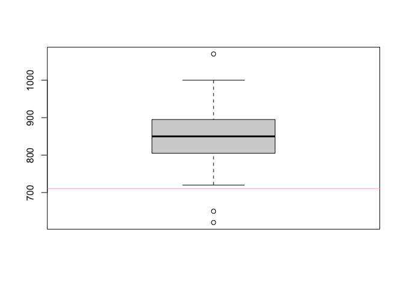

```r
boxplot(data$Speed)
abline(h = 710.5,
       col = "lightpink")
```

```r
boxplot(data$Speed,
        plot = F)$out
```

```
[1] 1070  650  620
```

Calculamos el IC al 99%

```r
t.test(x = data$Speed,
       mu = 710.5,
       conf.level = 0.99)
```

```
    One Sample t-test

data:  data$Speed
t = 17.96, df = 99, p-value < 2.2e-16
alternative hypothesis: true mean is not equal to 710.5
99 percent confidence interval:
 831.6486 873.1514
sample estimates:
mean of x
    852.4
```

Si solo se desea el IC:

```r
t.test(x = data$Speed, conf.level = 0.99)$conf.int
```

```
[1] 831.6486 873.1514
attr(,"conf.level")
[1] 0.99
```

## **Pregunta nº2:Prueba para 2 medias**

#### Muestras independientes

Se aplica cuando se comparan las medias de dos grupos independientes utilizando la prueba t para muestras independientes.

la funcion t.test trabaja por defecto con muestras independientes y no supone varianzas iguales

Comparamos 32 automoviles si existen diferencias significativas en el consumo entre los coches de transmision automatica y manual

```r
library(MASS)
library(ggplot2)
data("mtcars")
data = mtcars
dim(data)
```

```
[1] 32 11
```

```r
attach(data)

data %>% head()%>% kable(format = "html", escape = FALSE) %>%
  kable_styling("striped",
                full_width = FALSE,
                position = "center",
                font_size = 16)
```

|  | mpg | cyl | disp | hp | drat | wt | qsec | vs | am | gear | carb |
| --- | --- | --- | --- | --- | --- | --- | --- | --- | --- | --- | --- |
| Mazda RX4 | 21.0 | 6 | 160 | 110 | 3.90 | 2.620 | 16.46 | 0 | 1 | 4 | 4 |
| Mazda RX4 Wag | 21.0 | 6 | 160 | 110 | 3.90 | 2.875 | 17.02 | 0 | 1 | 4 | 4 |
| Datsun 710 | 22.8 | 4 | 108 | 93 | 3.85 | 2.320 | 18.61 | 1 | 1 | 4 | 1 |
| Hornet 4 Drive | 21.4 | 6 | 258 | 110 | 3.08 | 3.215 | 19.44 | 1 | 0 | 3 | 1 |
| Hornet Sportabout | 18.7 | 8 | 360 | 175 | 3.15 | 3.440 | 17.02 | 0 | 0 | 3 | 2 |
| Valiant | 18.1 | 6 | 225 | 105 | 2.76 | 3.460 | 20.22 | 1 | 0 | 3 | 1 |

· am: transmision (0= automatica, 1 = manual)

· mpg: millas/galon

```r
table(data[, "am"])
```

```
 0  1
19 13
```

```r
automatica = data$mpg[data$am == "0"]
automatica
```

```
 [1] 21.4 18.7 18.1 14.3 24.4 22.8 19.2 17.8 16.4 17.3 15.2 10.4 10.4 14.7 21.5
[16] 15.5 15.2 13.3 19.2
```

```r
manual = data$mpg[data$am == "1"]
manual
```

```
 [1] 21.0 21.0 22.8 32.4 30.4 33.9 27.3 26.0 30.4 15.8 19.7 15.0 21.4
```

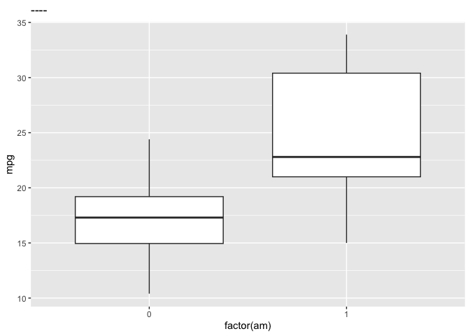

```r
ggplot(data,
       aes(factor(am), mpg)) +
  geom_boxplot() +
  labs(title = "----")
```

Al realizar una prueba estadística para comparar las medias de dos grupos, en este caso, el consumo de automóviles con transmisión automática (A) y manual (M), es esencial definir claramente las hipótesis nula (H0) y alternativa (H1). Estas hipótesis nos ayudan a determinar si existen diferencias estadísticamente significativas entre los dos grupos.

Definimos las hipótesis de la siguiente manera:

1. Hipótesis Nula (HO): $\mu_A \geq \mu_M$ ° Esta hipótesis afirma que la media de consumo de los automóviles con transmisión automática ( μA) es igual o mayor que la de los automóviles con transmisión manual ( μM ). Es una declaración de diferencia en una dirección específica (automática igual o mejor que manual en términos de consumo).
2. Hipótesis Alternativa (H1): $\mu_A < \mu_M$
- Esta hipótesis plantea que la media de consumo de los automóviles con transmisión automática es menor que la de los automóviles con transmisión manual. Es decir, sugiere que los automóviles con transmisión manual podrian ser más eficientes en cuanto a consumo de combustible.

La razón para definir las hipótesis de esta manera depende del contexto del estudio y lo que quieres probar. Si tu interés principal es averiguar si los automóviles con transmisión manual son más eficientes (es decir, tienen un mayor consumo de millas por galón), entonces definirías las hipótesis como lo has hecho. Esto establece un “test de una cola” donde solo te interesa si una media es significativamente menor que la otra, no si son diferentes.

En resumen, la manera en que defines tus hipótesis depende del objetivo específico de tu análisis y lo que estás tratando de demostrar o refutar con tus datos.

$H_0 : \mu_A \geq \mu_M$

$H_1 : \mu_A < \mu_M$

```r
t.test(formula = data$mpg ~ data$am,
       conf.level = 0.95)
```

```
    Welch Two Sample t-test

data:  data$mpg by data$am
t = -3.7671, df = 18.332, p-value = 0.001374
alternative hypothesis: true difference in means between group 0 and group 1 is not equal to 0
95 percent confidence interval:
 -11.280194  -3.209684
sample estimates:
mean in group 0 mean in group 1
       17.14737        24.39231
```

Al usar formula , toma la diferencia en orden alfabetico (1.- automatica y 2.- manual)

Tambien puede escribirse del siguiente modo

```r
t.test(formula = data$mpg ~ am,
       data = data,
       conf.level = 0.95)
```

```
    Welch Two Sample t-test

data:  data$mpg by am
t = -3.7671, df = 18.332, p-value = 0.001374
alternative hypothesis: true difference in means between group 0 and group 1 is not equal to 0
95 percent confidence interval:
 -11.280194  -3.209684
sample estimates:
mean in group 0 mean in group 1
       17.14737        24.39231
```

```r
t.test(automatica, manual , conf.level = 0.95)$conf.int
```

```
[1] -11.280194  -3.209684
attr(,"conf.level")
[1] 0.95
```

El hecho de que el IC obtenido esté formado solo por números negativos sugiere que el consumo medio de la transmisión automática es inferior al de la transmisión manual (orden en el que se han introducido en la función t.test).

```r
t.test(automatica, manual , conf.level = 0.95)$conf.int
```

```
[1] -11.280194  -3.209684
attr(,"conf.level")
[1] 0.95
```

#### Muestras pareadas

Se aplica cuando se comparan las medias de dos grupos relacionados utilizando la prueba t para muestras pareadas.

Cada conejillo de indias se ha sometido a las 3 dosis y a los 2 metodos

```r
library(datasets)
library(ggplot2)

data("ToothGrowth")

data = ToothGrowth

dim(data)
```

```
[1] 60  3
```

```r
attach(data)

data %>% head()%>% kable(format = "html", escape = FALSE) %>%
  kable_styling("striped",
                full_width = FALSE,
                position = "center",
                font_size = 16)
```

| len | supp | dose |
| --- | --- | --- |
| 4.2 | VC | 0.5 |
| 11.5 | VC | 0.5 |
| 7.3 | VC | 0.5 |
| 5.8 | VC | 0.5 |
| 6.4 | VC | 0.5 |
| 10.0 | VC | 0.5 |

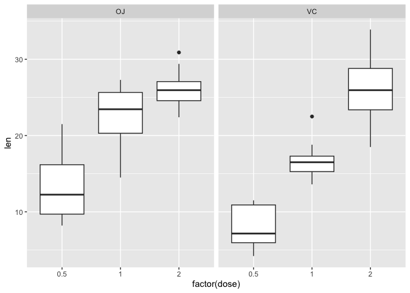

```r
ggplot(data,
       aes(factor(dose), len)) +
  geom_boxplot() +
  facet_grid(.~supp) +
  labs(tittle = "Dosis de vitamina C")
```

Para cada metodo el largo de los dientes aumenta al aumentar la dosis de vitamina c

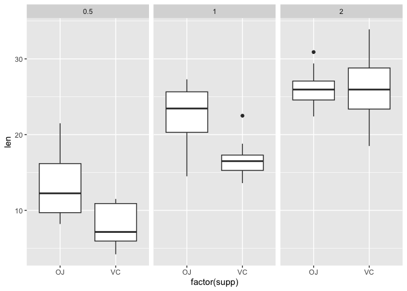

```r
ggplot(data,
       aes(factor(supp), len)) +
  geom_boxplot() +
  facet_grid(.~dose) +
  labs(tittle = "Metodos")
```

Para cada dosis, las diferencias entre los metodos no es tan clara.

Nos preguntamos si para cada dosis de vitamina C, existen diferencias significativas entre los dos metodos.

Transformacion de los datos

```r
data = transform(data,
                 dose = as.factor(dose))

s = split(data,
          list(data$supp,
               data$dose))
s
```

```
$OJ.0.5
    len supp dose
31 15.2   OJ  0.5
32 21.5   OJ  0.5
33 17.6   OJ  0.5
34  9.7   OJ  0.5
35 14.5   OJ  0.5
36 10.0   OJ  0.5
37  8.2   OJ  0.5
38  9.4   OJ  0.5
39 16.5   OJ  0.5
40  9.7   OJ  0.5

$VC.0.5
    len supp dose
```

[output cut: 62 more lines]

```r
# dose = 0.5

t1 = t.test(s[[1]][[1]],
            s[[2]][[1]],
            paired = TRUE,
            alternative = "greater")

t1
```

```
    Paired t-test

data:  s[[1]][[1]] and s[[2]][[1]]
t = 2.9791, df = 9, p-value = 0.007736
alternative hypothesis: true mean difference is greater than 0
95 percent confidence interval:
 2.019552      Inf
sample estimates:
mean difference
           5.25
```

Dosis de 0.5 mg:

Resultado: t = 2.9791, df = 9, p-value = 0.007736

Hipótesis alternativa: la diferencia verdadera de medias es mayor que 0.

Intervalo de confianza del 95%: [2.019552, Inf]

**La prueba t para muestras pareadas muestra que hay una diferencia significativa en el largo de los dientes a favor del método OJ sobre VC para la dosis de 0.5 mg (p < 0.01). La media de la diferencia es de 5.25 mm.**

```r
# dose = 1

t1 = t.test(s[[3]][[1]],
            s[[4]][[1]],
            paired = TRUE,
            alternative = "greater")

t1
```

```
    Paired t-test

data:  s[[3]][[1]] and s[[4]][[1]]
t = 3.3721, df = 9, p-value = 0.004115
alternative hypothesis: true mean difference is greater than 0
95 percent confidence interval:
 2.706401      Inf
sample estimates:
mean difference
           5.93
```

Dosis de 1 mg:

Resultado: t = 3.3721, df = 9, p-value = 0.004115

Hipótesis alternativa: la diferencia verdadera de medias es mayor que 0.

Intervalo de confianza del 95%: [2.706401, Inf]

**Similarmente, para la dosis de 1 mg, hay una diferencia significativa en el largo de los dientes a favor del método OJ sobre VC (p < 0.01). La media de la diferencia es de 5.93 mm.**

```r
# dose = 2

t1 = t.test(s[[5]][[1]],
            s[[6]][[1]],
            paired = TRUE,
            alternative = "greater")

t1
```

```
    Paired t-test

data:  s[[5]][[1]] and s[[6]][[1]]
t = -0.042592, df = 9, p-value = 0.5165
alternative hypothesis: true mean difference is greater than 0
95 percent confidence interval:
 -3.523109       Inf
sample estimates:
mean difference
          -0.08
```

Dosis de 2 mg:

Resultado: t = -0.042592, df = 9, p-value = 0.5165

Hipótesis alternativa: la diferencia verdadera de medias es mayor que 0.

Intervalo de confianza del 95%: [-3.523109, Inf]

**Para la dosis de 2 mg, no se encontró una diferencia significativa entre los métodos OJ y VC (p > 0.05). La media de la diferencia es de -0.08 mm, lo que indica que no hay una ventaja clara de un método sobre el otro a esta dosis.**

**Conclusión General** Para las dosis más bajas (0. 5 mg y 1 mg), el método de administración de vitamina C a través del zumo de naranja (OJ) mostró un efecto significativamente mayor en el crecimiento del largo de los dientes comparado con el ácido ascórbico (VC).

Sin embargo, para la dosis más alta (2 mg), no hubo una diferencia significativa entre los dos métodos de administración.

Esto sugiere que el método de administración puede influir en la efectividad de la vitamina C a dosis más bajas, pero a dosis más altas, el efecto de la administración se nivela

## **Pregunta nº3:Prueba para mas de 2 medias**

#### ANOVA inter-sujetos

Se aplica cuando se comparan las medias de más de dos grupos independientes utilizando ANOVA.

```r
data("InsectSprays")
data = InsectSprays
dim(data)
```

```
[1] 72  2
```

```r
data %>% head() %>% kable() %>%  kable_styling()
```

| count | spray |
| --- | --- |
| 10 | A |
| 7 | A |
| 20 | A |
| 14 | A |
| 14 | A |
| 12 | A |

```r
table(data$spray)
```

```
 A  B  C  D  E  F
12 12 12 12 12 12
```

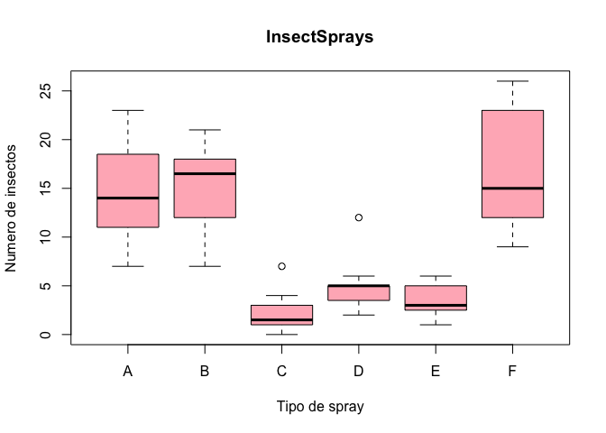

```r
boxplot(count ~ spray,
        data = data,
        xlab = "Tipo de spray",
        ylab = "Numero de insectos",
        main = "InsectSprays",
        varwidth = TRUE,
        col = "lightpink")
```

Observamos que hay diferencias en la efectividad de los spray, aunque es dificil establecer cual es mas efectivo

```r
m1 = aov(count ~spray,
         data = data)

summary(m1)
```

```
            Df Sum Sq Mean Sq F value Pr(>F)
spray        5   2669   533.8    34.7 <2e-16 ***
Residuals   66   1015    15.4
---
Signif. codes:  0 '***' 0.001 '**' 0.01 '*' 0.05 '.' 0.1 ' ' 1
```

Existen diferencias significativas en la efectividad de los spray

Las pruebas posthoc de Tukey nos permite determinar entre que sprays hay diferencias significativas

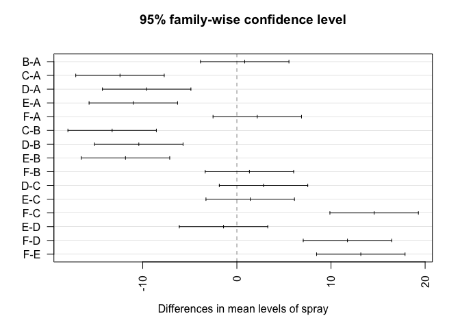

```r
plot(TukeyHSD(m1),
     las = 2)
```

```r
TukeyHSD(m1)
```

```
  Tukey multiple comparisons of means
    95% family-wise confidence level

Fit: aov(formula = count ~ spray, data = data)

$spray
           diff        lwr       upr     p adj
B-A   0.8333333  -3.866075  5.532742 0.9951810
C-A -12.4166667 -17.116075 -7.717258 0.0000000
D-A  -9.5833333 -14.282742 -4.883925 0.0000014
E-A -11.0000000 -15.699409 -6.300591 0.0000000
F-A   2.1666667  -2.532742  6.866075 0.7542147
C-B -13.2500000 -17.949409 -8.550591 0.0000000
D-B -10.4166667 -15.116075 -5.717258 0.0000002
E-B -11.8333333 -16.532742 -7.133925 0.0000000
F-B   1.3333333  -3.366075  6.032742 0.9603075
D-C   2.8333333  -1.866075  7.532742 0.4920707
E-C   1.4166667  -3.282742  6.116075 0.9488669
F-C  14.5833333   9.883925 19.282742 0.0000000
E-D  -1.4166667  -6.116075  3.282742 0.9488669
F-D  11.7500000   7.050591 16.449409 0.0000000
F-E  13.1666667   8.467258 17.866075 0.0000000
```

Aquellos intervalos que contienen el 0, no son significativos (ej. B-A)

C-A Presenta un intervalo negativo lo cual es decir que C<A

Si comprobamos los supuestos de homocedasticidad y de normalidad

```r
bartlett.test(count ~ spray,
              data = data)
```

```
    Bartlett test of homogeneity of variances

data:  count by spray
Bartlett's K-squared = 25.96, df = 5, p-value = 9.085e-05
```

```r
shapiro.test(data$count)
```

```
    Shapiro-Wilk normality test

data:  data$count
W = 0.9216, p-value = 0.0002525
```

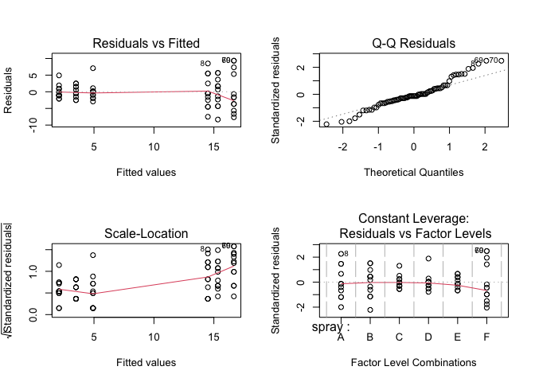

```r
opar = par(mfrow = c(2,2),
           oma = c(0, 0, 0.1,0))
plot(m1)
```

#### ANOVA intra-sujetos o de medidas repeditas

Se aplica cuando se comparan las medias de más de dos grupos relacionados utilizando ANOVA para medidas repetidas.

```r
library(ez)
library(WRS2)


data(WineTasting)

data = WineTasting

dim(data)
```

```
[1] 66  3
```

```r
attach(data)

data %>% head() %>% kable() %>% kable_styling()
```

| Taste | Wine | Taster |
| --- | --- | --- |
| 5.40 | Wine A | 1 |
| 5.50 | Wine B | 1 |
| 5.55 | Wine C | 1 |
| 5.85 | Wine A | 2 |
| 5.70 | Wine B | 2 |
| 5.75 | Wine C | 2 |

```r
data$Wine = as.factor(data$Wine)
```

```r
ezANOVA(data = data,
        dv = Taste,
        wid = Taster,
        within = Wine)
```

```
$ANOVA
  Effect DFn DFd        F           p p<.05        ges
2   Wine   2  42 6.288308 0.004084101     * 0.02026075

$`Mauchly's Test for Sphericity`
  Effect         W          p p<.05
2   Wine 0.7071776 0.03128132     *

$`Sphericity Corrections`
  Effect       GGe       p[GG] p[GG]<.05       HFe       p[HF] p[HF]<.05
2   Wine 0.7735015 0.008439799         * 0.8233709 0.007188822         *
```

```r
with(data,
     pairwise.t.test(Taste,
                     Wine,
                     p.adjust.method = "bonferroni",
                     paired = TRUE))
```

```
    Pairwise comparisons using paired t tests

data:  Taste and Wine

       Wine A Wine B
Wine B 1.000  -
Wine C 0.043  0.002

P value adjustment method: bonferroni
```

## **Pregunta nº4:Prueba para 1 varianza**

Vamos a crear una variable aleatoria de distribucion normal con media 15 y desviacion estandar 7

Queremos contrastar si la desviacion estandar poblacional es de 6

```r
library(TeachingDemos)

x = rnorm(100,
          mean = 15,
          sd = 7)
```

```r
sigma.test(x,
           sigma = 6)
```

```
    One sample Chi-squared test for variance

data:  x
X-squared = 123.87, df = 99, p-value = 0.09208
alternative hypothesis: true variance is not equal to 36
95 percent confidence interval:
 34.72437 60.78663
sample estimates:
var of x
45.04417
```

1.-Hipótesis nula (H0): La varianza poblacional es igual a 36 (σ² = 36, donde σ = 6).

## **Pregunta nº5:Prueba para 2 varianzas**

Tenemos 3 metodos

Prueba F: Para comparar las varianzas de 2 muestras que provienen de poblaciones normales

Prueba de Bartlett: Es la mejor cuando los datos tienen distribucion normal

Prueba de Lavane: Es mas robusta frente a desviaciones de la normalidad

```r
data(iris)

data = iris
```

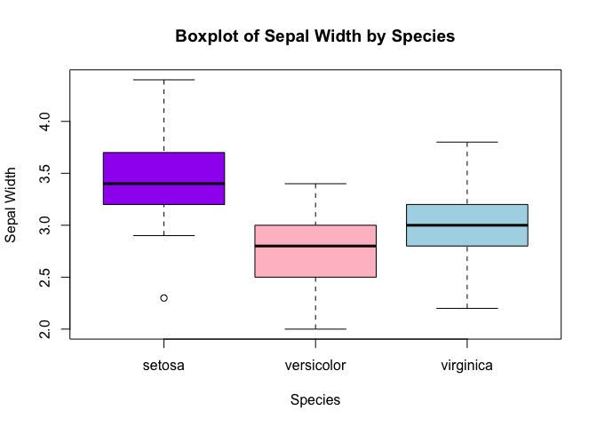

```r
boxplot(Sepal.Width ~ Species,
        data = iris,
        col = c("purple", "pink", "lightblue"),
        main = "Boxplot of Sepal Width by Species",
        xlab = "Species",
        ylab = "Sepal Width")
```

La prueba F

Se utiliza para comparar las varianzas de dos poblaciones y determinar si son significativamente diferentes. En este caso, la prueba F se aplica a la variable Sepal.Width entre las especies de flores del dataset iris.

```r
# Prueba F

var.test(Sepal.Width ~Species,
         data,
         Species %in%c("versicolor", "virginica"))
```

```
    F test to compare two variances

data:  Sepal.Width by Species
F = 0.94678, num df = 49, denom df = 49, p-value = 0.849
alternative hypothesis: true ratio of variances is not equal to 1
95 percent confidence interval:
 0.5372773 1.6684117
sample estimates:
ratio of variances
         0.9467839
```

Hipótesis nula (H0): Las varianzas de Sepal.Width entre las especies son iguales (razón de varianzas = 1).

Hipótesis alternativa (H1): Las varianzas de Sepal.Width entre las especies no son iguales (razón de varianzas ≠ 1).

El intervalo de confianza del 95% para la razón de varianzas [0.5372773, 1.6684117] incluye el valor 1, lo que respalda aún más la conclusión de que no hay una diferencia significativa en las varianzas.

## **Pregunta nº6:Prueba para mas de 2 varianzas**

```r
data("InsectSprays")
data = InsectSprays
```

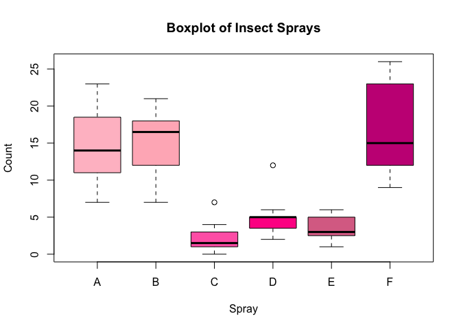

```r
boxplot(count ~ spray,
        data = data,
        col = c("#FFC0CB", "#FFB6C1", "#FF69B4", "#FF1493", "#DB7093", "#C71585"),
        main = "Boxplot of Insect Sprays",
        xlab = "Spray",
        ylab = "Count")
```

```r
bartlett.test(count ~spray,
              data = data)
```

```
    Bartlett test of homogeneity of variances

data:  count by spray
Bartlett's K-squared = 25.96, df = 5, p-value = 9.085e-05
```

Para Datos que no cumplen los supuestos de normalidad y homogeneidad de la varianza

Para 2 muestras: ansan.test, mood.test

Para mas de 2 muestras: flinger.test

## **Pregunta nº7:Prueba para 1 proporcion**

Tiramos 1 moneda 100 veces y nos preguntamos si la proporcion de caras puede ser del 50%

```r
set.seed(123)

caras <- rbinom(1, size = 100, prob = 0.5)

caras
```

```
[1] 49
```

```r
binom.test(caras, 100)
```

```
    Exact binomial test

data:  caras and 100
number of successes = 49, number of trials = 100, p-value = 0.9204
alternative hypothesis: true probability of success is not equal to 0.5
95 percent confidence interval:
 0.3886442 0.5919637
sample estimates:
probability of success
                  0.49
```

Hipótesis nula (H0): La proporción de caras es 0.5 (50%).

Hipótesis alternativa (H1): La proporción de caras no es 0.5 (50%).

El valor p es 0.9204, que es mucho mayor que el nivel de significancia comúnmente utilizado (α = 0.05). Esto indica que no hay suficiente evidencia para rechazar la hipótesis nula. En otras palabras, no se puede concluir que la proporción de caras sea significativamente diferente de 0.5.

El intervalo de confianza del 95% para la proporción de caras [0.3886442, 0.5919637] incluye el valor 0.5, lo que refuerza la conclusión de que la proporción de caras no es significativamente diferente de 0.5.

```r
prop.test(caras, 100)
```

```
    1-sample proportions test with continuity correction

data:  caras out of 100, null probability 0.5
X-squared = 0.01, df = 1, p-value = 0.9203
alternative hypothesis: true p is not equal to 0.5
95 percent confidence interval:
 0.3894281 0.5913488
sample estimates:
   p
0.49
```

Estimación de la proporción de éxito: La proporción observada de caras es 0.49, muy cercana al valor esperado de 0.5.

## **Pregunta nº8:Prueba para 2 proporciones**

Vamos a evaluar si la proporcion de mujeres que fuman es diferente de la proporcion de los hombres que fuman

```r
valores = matrix(c(70, 120, 65, 140),
                 ncol = 2,
                 byrow = TRUE)
rownames(valores) = c("hombre", "mujer")

colnames(valores) = c("fuma", "no_fuma")
```

```r
prop.test(valores)
```

```
    2-sample test for equality of proportions with continuity correction

data:  valores
X-squared = 0.93871, df = 1, p-value = 0.3326
alternative hypothesis: two.sided
95 percent confidence interval:
 -0.04732922  0.15002498
sample estimates:
   prop 1    prop 2
0.3684211 0.3170732
```

Valor p: El valor p de 0.3326 es mucho mayor que el nivel de significancia comúnmente utilizado (α = 0.05). Esto indica que no hay suficiente evidencia para rechazar la hipótesis nula. En otras palabras, no se puede concluir que las proporciones de hombres y mujeres que fuman sean significativamente diferentes.

Intervalo de confianza: El intervalo de confianza del 95% para la diferencia de proporciones [-0.04732922, 0.15002498] incluye el valor 0, lo que respalda aún más la conclusión de que no hay una diferencia significativa en las proporciones de hombres y mujeres que fuman.

## **Pregunta nº9:Prueba para mas de 2 proporciones**

Se conoce el numero de fumadores que hay en 4 cuidades

Se puede contrastar

```r
fumadores = c(83, 90, 129, 70)
no_fumadores = c(86, 93, 136, 82)
prop.test(fumadores, no_fumadores)
```

```
    4-sample test for equality of proportions without continuity correction

data:  fumadores out of no_fumadores
X-squared = 12.6, df = 3, p-value = 0.005585
alternative hypothesis: two.sided
sample estimates:
   prop 1    prop 2    prop 3    prop 4
0.9651163 0.9677419 0.9485294 0.8536585
```

Valor p: El valor p de 0.005585 es menor que el nivel de significancia comúnmente utilizado (α = 0.05). Esto indica que hay suficiente evidencia para rechazar la hipótesis nula. En otras palabras, se puede concluir que al menos una de las proporciones de fumadores es significativamente diferente de las demás.

Estimaciones de las proporciones: Las proporciones de fumadores en las ciudades 1 y 2 son muy similares (0.965 y 0.968, respectivamente), mientras que la proporción en la ciudad 3 es un poco menor (0.949) y la proporción en la ciudad 4 es significativamente menor (0.854).